# Import libraries

# Target Variables

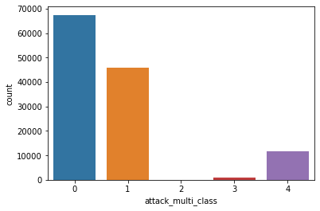

```python
# countplot of multi class classification
sns.countplot(train_enc.attack_multi_class)
```

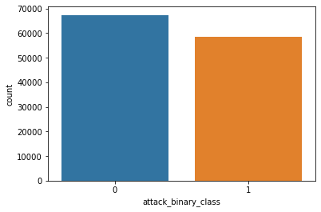

```python
# countplot of binary class classification
sns.countplot(train_enc.attack_binary_class)
```

reference documents  
http://45.113.122.54/pdfs/ijrscse/v2-i3/7.pdf  
http://kdd.ics.uci.edu/databases/kddcup99/task.html

# Train Test Split

```python
from sklearn.model_selection import train_test_split
```

```python
# train
X_train_final = train_enc.drop(['attack_multi_class', 'attack_binary_class'], axis=1)

# test
X_test_final = test_enc.drop(['attack_multi_class', 'attack_binary_class'], axis=1)
```

### Binary Classification

```python
# train
y_train_binary_final = train_enc['attack_binary_class']

# test
y_test_binary_final = test_enc['attack_binary_class']
```

```python
X_train, X_test, y_train, y_test = train_test_split(X_train_final, y_train_binary_final, test_size=0.2, random_state=42)
```

```python
X_train.shape, y_train.shape
```

```
((100777, 42), (100777,))
```

```python
X_train.shape, X_test.shape, y_train.shape, y_test.shape
```

```
((100777, 42), (25195, 42), (100777,), (25195,))
```

# Variance Of Features

```python
from sklearn.feature_selection import VarianceThreshold
```

```python
var = VarianceThreshold(threshold=0.1)
```

```python
var.fit(X_train_final)
```

```
VarianceThreshold(threshold=0.1)
```

```python
unwanted_columns = []
```

```python
X_train_final.iloc[:, ~var.get_support()].columns
```

```
Index(['land', 'wrong_fragment', 'urgent', 'num_failed_logins', 'root_shell',
       'su_attempted', 'num_shells', 'num_access_files', 'num_outbound_cmds',
       'is_host_login', 'is_guest_login', 'diff_srv_rate',
       'srv_diff_host_rate', 'dst_host_diff_srv_rate',
       'dst_host_same_src_port_rate', 'dst_host_srv_diff_host_rate',
       'dst_host_rerror_rate'],
      dtype='object')
```

```python
unwanted_columns = ['land', 'wrong_fragment', 'urgent', 'num_failed_logins', 'root_shell',
       'su_attempted', 'num_shells', 'num_access_files', 'num_outbound_cmds',
       'is_host_login', 'is_guest_login', 'diff_srv_rate',
       'srv_diff_host_rate', 'dst_host_diff_srv_rate',
       'dst_host_same_src_port_rate', 'dst_host_srv_diff_host_rate',
       'dst_host_rerror_rate']
```

```python
unwanted_columns
```

```
['land',
 'wrong_fragment',
 'urgent',
 'num_failed_logins',
 'root_shell',
 'su_attempted',
 'num_shells',
 'num_access_files',
 'num_outbound_cmds',
 'is_host_login',
 'is_guest_login',
 'diff_srv_rate',
 'srv_diff_host_rate',
 'dst_host_diff_srv_rate',
 'dst_host_same_src_port_rate',
 'dst_host_srv_diff_host_rate',
 'dst_host_rerror_rate']
```

# Correlation between Features

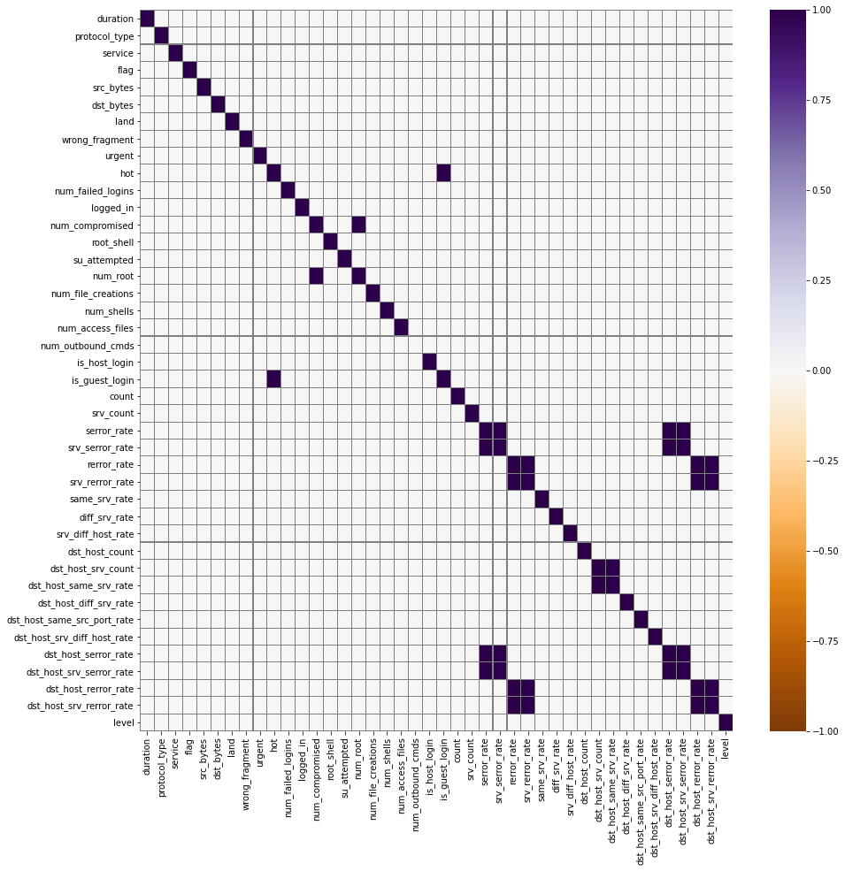

```python
plt.figure(figsize=(15, 15))
sns.heatmap(X_train_final.corr()>0.8, cmap='PuOr', vmin=-1, vmax=1, linecolor='gray', linewidths=0.1)
```

is_guest_login--------------host  
num_root--------------------num_compromised  
srv_serror_rate-------------serror_rate  
dst_host_serror_rate--------serror_rate  
dst_host_srv_serror_rate----serror_rate  
srv_rerror_rate-------------rerror_rate  
dst_host_rerror_rate--------rerror_rate  
dst_host_srv_rerror_rate----rerror_rate  
dst_host_same_srv_rate------dst_host_srv_counts  
dst_host_srv_serror_rate----dst_host_serror_rate  
dst_host_srv_rerror_rate----dst_host_rerror_rate

# Strongly correlated Features

```python
corr_matrix = X_train_final.corr().abs()
high_corr_var=np.where(corr_matrix>0.8)
high_corr_var=[(corr_matrix.columns[y].ljust(30, ' '),corr_matrix.columns[x]) for x,y in zip(*high_corr_var) if x!=y and x<y]
```

```python
# below feature are strongly correlated with each other we can remove one of each
high_corr_var
```

```
[('is_guest_login                ', 'hot'),
 ('num_root                      ', 'num_compromised'),
 ('srv_serror_rate               ', 'serror_rate'),
 ('dst_host_serror_rate          ', 'serror_rate'),
 ('dst_host_srv_serror_rate      ', 'serror_rate'),
 ('dst_host_serror_rate          ', 'srv_serror_rate'),
 ('dst_host_srv_serror_rate      ', 'srv_serror_rate'),
 ('srv_rerror_rate               ', 'rerror_rate'),
 ('dst_host_rerror_rate          ', 'rerror_rate'),
 ('dst_host_srv_rerror_rate      ', 'rerror_rate'),
 ('dst_host_rerror_rate          ', 'srv_rerror_rate'),
 ('dst_host_srv_rerror_rate      ', 'srv_rerror_rate'),
 ('dst_host_same_srv_rate        ', 'dst_host_srv_count'),
 ('dst_host_srv_serror_rate      ', 'dst_host_serror_rate'),
 ('dst_host_srv_rerror_rate      ', 'dst_host_rerror_rate')]
```

```python
# finding unwanted features
a = [x.strip() for x, _ in high_corr_var]
```

```python
unwanted_columns.extend(a)
```

```python
# all unwanted features
unwanted_columns
```

```
['land',
 'wrong_fragment',
 'urgent',
 'num_failed_logins',
 'root_shell',
 'su_attempted',
 'num_shells',
 'num_access_files',
 'num_outbound_cmds',
 'is_host_login',
 'is_guest_login',
 'diff_srv_rate',
 'srv_diff_host_rate',
 'dst_host_diff_srv_rate',
 'dst_host_same_src_port_rate',
 'dst_host_srv_diff_host_rate',
 'dst_host_rerror_rate',
 'is_guest_login',
 'num_root',
 'srv_serror_rate',
 'dst_host_serror_rate',
 'dst_host_srv_serror_rate',
 'dst_host_serror_rate',
 'dst_host_srv_serror_rate',
 'srv_rerror_rate',
 'dst_host_rerror_rate',
 'dst_host_srv_rerror_rate',
 'dst_host_rerror_rate',
 'dst_host_srv_rerror_rate',
 'dst_host_same_srv_rate',
 'dst_host_srv_serror_rate',
 'dst_host_srv_rerror_rate']
```

```python
len(unwanted_columns)
```

```
32
```

# Drop Unwanted Columns

```python
# dropping unwanted features
XX_train = X_train_final.drop(unwanted_columns, 1)
XX_test = X_test_final.drop(unwanted_columns, 1)
```

```python
XX_train.shape, XX_test.shape
```

```
((125972, 18), (22543, 18))
```

# Import Classification Algorithams

```python
from sklearn.linear_model import LogisticRegression   #1
from sklearn.linear_model import SGDClassifier        #2
from sklearn.neighbors import KNeighborsClassifier    #3
from sklearn.tree import DecisionTreeClassifier       #4
from sklearn.ensemble import RandomForestClassifier   #5
from sklearn.naive_bayes import GaussianNB            #6
from sklearn.svm import SVC                           #7
```

# Pipelines

```python
from sklearn.pipeline import Pipeline
from sklearn.preprocessing import StandardScaler
from sklearn.decomposition import PCA
```

```python
# creating pipelines for each classifire

# Logistic Regressoin
pipeline_lr = Pipeline([('scaler_lr', StandardScaler()),
                      ('pca_lr', PCA(n_components=3)),
                      ('model_lr', LogisticRegression(random_state=0))])

# SGDClassifire
pipeline_sgd = Pipeline([('scaler_sgd', StandardScaler()),
                      ('pca_sgd', PCA(n_components=3)),
                      ('model_sgd', SGDClassifier())])

# KNN
pipeline_knn = Pipeline([('scaler_knn', StandardScaler()),
                      ('pca_knn', PCA(n_components=3)),
                      ('model_knn', KNeighborsClassifier(n_neighbors=355))])

# DecisionTree Classifier
pipeline_dt = Pipeline([('scaler_dt', StandardScaler()),
                      ('pca_dt', PCA(n_components=3)),
                      ('model_dt', DecisionTreeClassifier())])

# RandomForest Classifier
pipeline_rf = Pipeline([('scaler_rf', StandardScaler()),
                      ('pca_rf', PCA(n_components=3)),
                      ('model_rf', RandomForestClassifier())])

# GaussianNB
pipeline_gnb = Pipeline([('scaler_gnb', StandardScaler()),
                      ('pca_gnb', PCA(n_components=3)),
                      ('model_gnb', GaussianNB())])

# SVC
pipeline_svc = Pipeline([('scaler_svc', StandardScaler()),
                      ('pca_svc', PCA(n_components=3)),
                      ('model_svc', SVC(kernel='linear'))])
```

```python
# creating list of pipelines
pipelines = [pipeline_lr, pipeline_sgd, pipeline_knn, pipeline_dt, pipeline_rf, pipeline_gnb, pipeline_svc]


pipe_dict = {0:'LogisticRegression',
             1:'SGDClassifier',
             2:'KNeighborsClassifier',
             3:'DecisionTreeClassifier',
             4:'RandomForestClassifier',
             5:'GaussianNB',
             6:'SVC'}

# list of classifire names
model_names = ['LogisticRegression',
             'SGDClassifier',
             'KNeighborsClassifier',
             'DecisionTreeClassifier',
             'RandomForestClassifier',
             'GaussianNB',
             'SVC']
```

```python
# binary classification
# traing each model with pipeline

for pipe in pipelines:
    pipe.fit(XX_train, y_train_binary_final)
```

```python
# finding score of train and test data

train_acc = []
test_acc = []
for pipe_pred in pipelines:
    train_acc.append(pipe_pred.score(XX_train, y_train_binary_final))
    test_acc.append(pipe_pred.score(XX_test, y_test_binary_final))
```

```python
# creating dataframe for train and test data with thier acuuracy scores
accuracies = pd.DataFrame({'Model Name':model_names, 'Train Accuracy': train_acc, 'Test Accuracy':test_acc})
```

```python
accuracies
```

|  | Model Name | Train Accuracy | Test Accuracy |
| --- | --- | --- | --- |
| 0 | LogisticRegression | 0.897723 | 0.806148 |
| 1 | SGDClassifier | 0.900613 | 0.800736 |
| 2 | KNeighborsClassifier | 0.977860 | 0.852194 |
| 3 | DecisionTreeClassifier | 0.997650 | 0.867586 |
| 4 | RandomForestClassifier | 0.999500 | 0.867453 |
| 5 | GaussianNB | 0.882267 | 0.800115 |
| 6 | SVC | 0.895723 | 0.789957 |

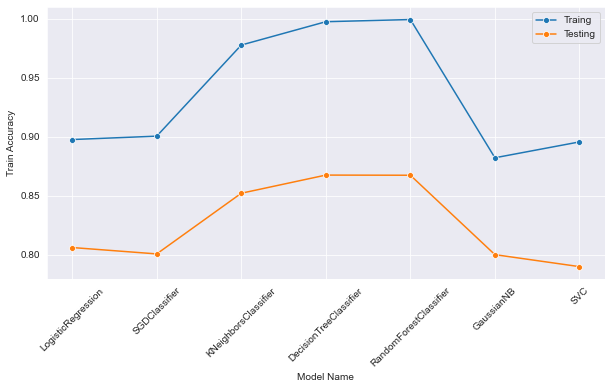

```python
# plotting line plot of traing vs test

plt.figure(figsize=(10, 5))
sns.set_style('darkgrid')
sns.lineplot(accuracies['Model Name'], accuracies['Train Accuracy'], marker='o', label='Traing')
sns.lineplot(accuracies['Model Name'], accuracies['Test Accuracy'], marker='o', label='Testing')

plt.xticks(rotation=45)
plt.show()
```

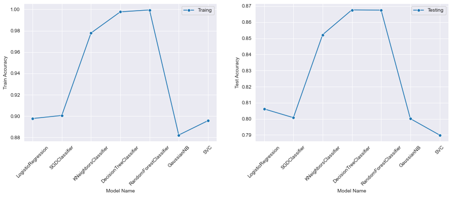

```python
# separate plots for trainng and testing accuracy score

plt.figure(figsize=(15, 5))

plt.subplot(1,2,1)
sns.lineplot(accuracies['Model Name'], accuracies['Train Accuracy'], marker='o', label='Traing')
plt.xticks(rotation=45)

plt.subplot(1,2,2)
sns.lineplot(accuracies['Model Name'], accuracies['Test Accuracy'], marker='o', label='Testing')
plt.xticks(rotation=45)
plt.show()
```

## Multi Classification

```python
# train
y_train_multi_final = train_enc['attack_multi_class']

# test
y_test_multi_final = test_enc['attack_multi_class']
```

```python
# multi-class classification
for pipe in pipelines:
    pipe.fit(XX_train, y_train_multi_final)
```

```python
train_acc_multi = []
test_acc_multi = []
for pipe_pred in pipelines:
    train_acc_multi.append(pipe_pred.score(XX_train, y_train_multi_final))
    test_acc_multi.append(pipe_pred.score(XX_test, y_test_multi_final))
```

```python
accuracies_multi = pd.DataFrame({'Model Name':model_names, 'Train Accuracy': train_acc_multi, 'Test Accuracy':test_acc_multi})
```

```python
accuracies_multi
```

|  | Model Name | Train Accuracy | Test Accuracy |
| --- | --- | --- | --- |
| 0 | LogisticRegression | 0.870257 | 0.722087 |
| 1 | SGDClassifier | 0.882617 | 0.777714 |
| 2 | KNeighborsClassifier | 0.955125 | 0.726212 |
| 3 | DecisionTreeClassifier | 0.997341 | 0.780553 |
| 4 | RandomForestClassifier | 0.998119 | 0.761079 |
| 5 | GaussianNB | 0.858889 | 0.706162 |
| 6 | SVC | 0.871408 | 0.737213 |

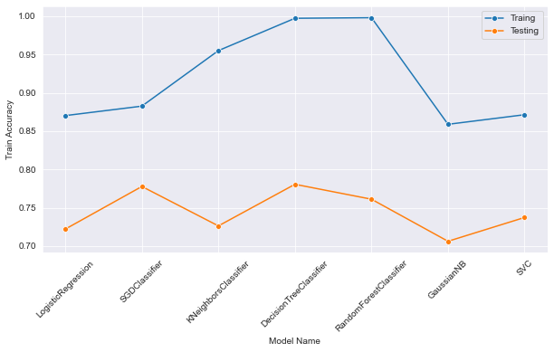

```python
plt.figure(figsize=(10, 5))
sns.set_style('darkgrid')
sns.lineplot(accuracies_multi['Model Name'], accuracies_multi['Train Accuracy'], marker='o', label='Traing')
sns.lineplot(accuracies_multi['Model Name'], accuracies_multi['Test Accuracy'], marker='o', label='Testing')

plt.xticks(rotation=45)
plt.show()
```

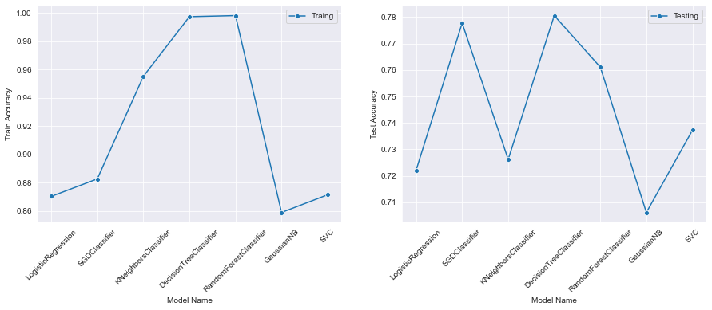

```python
plt.figure(figsize=(15, 5))

plt.subplot(1,2,1)
sns.lineplot(accuracies_multi['Model Name'], accuracies_multi['Train Accuracy'], marker='o', label='Traing')
plt.xticks(rotation=45)

plt.subplot(1,2,2)
sns.lineplot(accuracies_multi['Model Name'], accuracies_multi['Test Accuracy'], marker='o', label='Testing')
plt.xticks(rotation=45)
plt.show()
```